# Notebook 19 – Solutions

## Getting Started

Before running this notebook, select “Session > Restart R and Clear Output” in the menu above to start a new R session. This will clear any old data sets and give us a blank slate to start with.

## French COVID-19 Data

Here are the three French datasets that we will be working with. They contain spatial information, population metadata, and coronavirus numbers at the level of French *départements*. These are geographic areas that are an important political entities in France. There are 101 départements; 96 in mainland Europe and 5 overseas (called the *DOM*, or Départements d’outre-mer).

```r
dept <- read_sf(file.path("data", "france_departement.geojson"))
pop <- read_csv(file.path("data", "france_departement_population.csv"))
covid <- read_csv(file.path("data", "france_departement_covid.csv"))
```

The coronavirus data is stored with one row for each combination of day and département. We have the cumulative number of people who died in each day from COVID-19, the total number currently in hospital, the total number currently in *reanimation* (this is similar to ICU, but not exactly equivalent, so I used the french term here), and the cumulative number of newly recovered. Notice that deceased and recovered are the *total* counts of people who have died or recovered, whereas hospitalised and reanimation are the numbers at that moment of patients in each group. There are columns indicating the number of new hospitalisations and reanimations, but these have many missing data points.

## Practice

### Map projections

To get a better sense of how map projections work, slice the `dept` data to include only rows 96-101. This gives one département in Europe and all of the DOM. Plot the data using both `geom_sf` and `geom_sf_text` (for a label, use `departement_name`). Do not project the data, so that it uses just longitude and latitude. Note that Val-d’Oise is in Europe.

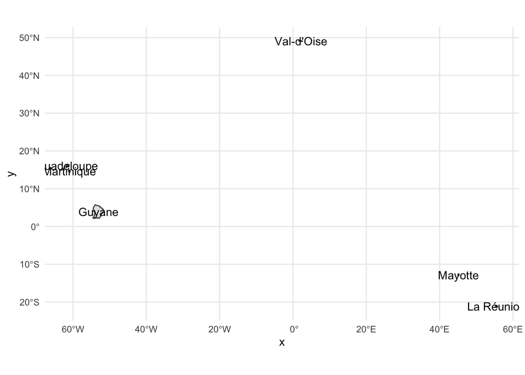

```r
dept %>%
  slice(96:101) %>%
  ggplot() +
    geom_sf() +
    geom_sf_text(aes(label = departement_name))
```

Take the code from above and use the EPSG-3943 projection; this was recommend for use with European France. Notice that the European part of the map has the lat- and lon- lines the closest to parallel to the x- and y-axes.

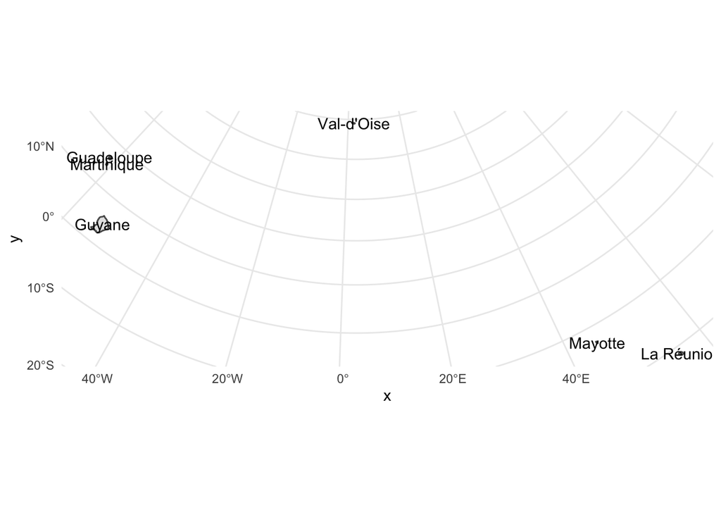

```r
dept %>%
  st_transform(3943) %>%
  slice(96:101) %>%
  ggplot() +
    geom_sf() +
    geom_sf_text(aes(label = departement_name))
```

Finally, use the EPSG-5879 projection with the same data:

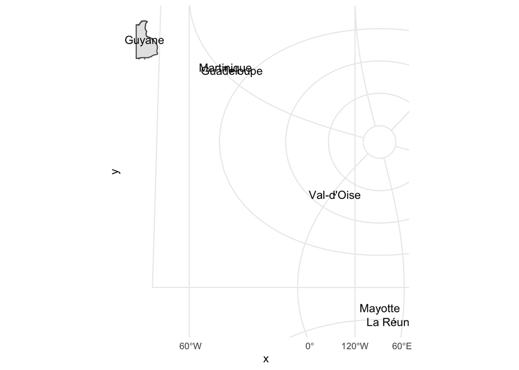

```r
dept %>%
  st_transform(5879) %>%
  slice(96:101) %>%
  ggplot() +
    geom_sf() +
    geom_sf_text(aes(label = departement_name))
```

### Population Density

Combine the methods in the notes to add a population density variable to the dataset (people per square kilometer). Plot the data spatially using color to show the population density for the first 96 rows of the dataset. Use a viridis color scale and appropropriate projection.

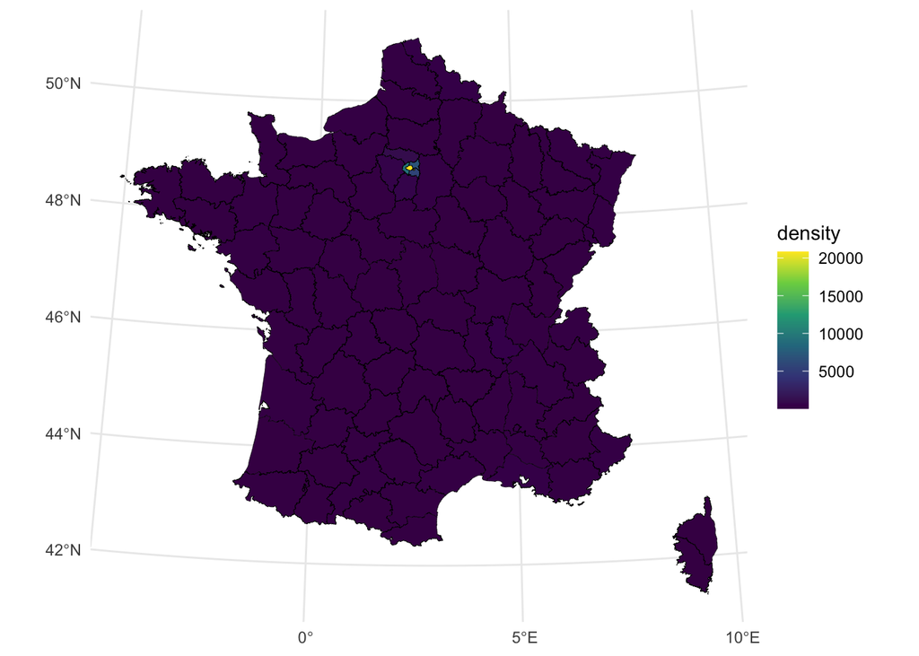

```r
dept %>%
  mutate(area = as.numeric(set_units(st_area(geometry), "km^2"))) %>%
  left_join(pop, by = "departement") %>%
  mutate(density = population / area) %>%
  slice(1:96) %>%
  st_transform(3943) %>%
  ggplot() +
    geom_sf(aes(fill = density), color = "black", size = 0.1) +
    scale_fill_viridis_c()
```

You should see that Paris and the the surrounding areas are by far the most dense areas. This is because they are the only départements that include only a dense city area and not any of the surrounding countryside. To fix this we need to be more careful about how we define a color palette.

Usually, we use color only as a secondary element in a plot. However, in a map we often need to use color to show the main feature of interest. This means that we have to be fairly careful about how colors are defined. Change the plot from your previous question to have the following scale:

- `scale_fill_distiller(trans = "log2", palette = "Spectral", guide = "legend", n.breaks = 10)`

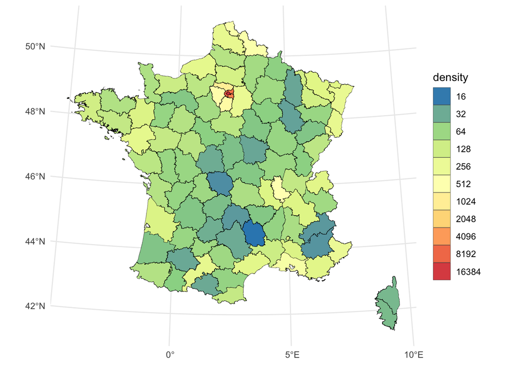

```r
dept %>%
  mutate(area = as.numeric(set_units(st_area(geometry), "km^2"))) %>%
  left_join(pop, by = "departement") %>%
  mutate(density = population / area) %>%
  slice(1:96) %>%
  st_transform(3943) %>%
  ggplot() +
    geom_sf(aes(fill = density), color = "black", size = 0.1) +
    scale_fill_distiller(trans = "log2", palette = "Spectral", guide = "legend", n.breaks = 10)
```

Other options for palettes include:

- **Diverging:** BrBG, PiYG, PRGn, PuOr, RdBu, RdGy, RdYlBu, RdYlGn, Spectral
- **Qualitative:** Accent, Dark2, Paired, Pastel1, Pastel2, Set1, Set2, Set3
- **Sequential:** Blues, BuGn, BuPu, GnBu, Greens, Greys, Oranges, OrRd, PuBu, PuBuGn, PuRd, Purples, RdPu, Reds, YlGn, YlGnBu, YlOrBr, YlOrRd

Keep this in mind as we continue to work with spatial data, as the defaults will often look terrible and be hard to interpret.

### Creating spatial data

It is time to get a little bit more complicated. Let’s read in a dataset of the largest French cities:

```r
cities <- read_csv(file.path("data", "france_cities.csv"))
cities
```

```
## # A tibble: 58 × 5
##    city         lat    lon population admin_name
##    <chr>      <dbl>  <dbl>      <dbl> <chr>
##  1 Paris       48.9  2.33     9904000 Ile-de-France
##  2 Lyon        45.8  4.83     1423000 Auvergne-Rhone-Alpes
##  3 Marseille   43.3  5.38     1400000 Provence-Alpes-Cote d'Azur
##  4 Lille       50.6  3.08     1044000 Hauts-de-France
##  5 Nice        43.7  7.26      927000 Provence-Alpes-Cote d'Azur
##  6 Toulouse    43.6  1.45      847000 Occitanie
##  7 Bordeaux    44.8 -0.595     803000 Nouvelle-Aquitaine
##  8 Rouen       49.4  1.08      532559 Normandie
##  9 Strasbourg  48.6  7.75      439972 Grand Est
## 10 Nantes      47.2 -1.59      438537 Pays de la Loire
## # … with 48 more rows
```

This is just a normal data frame object, but we can convert it into a spatial object with the following code:

```r
cities <- st_as_sf(cities, coords = c("lon", "lat"), remove = FALSE)
st_crs(cities) <- 4326  # set the default projection; EPSG-4326 => lat/long
cities
```

```
## Simple feature collection with 58 features and 5 fields
## Geometry type: POINT
## Dimension:     XY
## Bounding box:  xmin: -4.495 ymin: 41.9271 xmax: 9.45 ymax: 50.9504
## Geodetic CRS:  WGS 84
## # A tibble: 58 × 6
##    city         lat    lon population admin_name                         geometry
##  * <chr>      <dbl>  <dbl>      <dbl> <chr>                           <POINT [°]>
##  1 Paris       48.9  2.33     9904000 Ile-de-France              (2.3333 48.8667)
##  2 Lyon        45.8  4.83     1423000 Auvergne-Rhone-Alpes           (4.83 45.77)
##  3 Marseille   43.3  5.38     1400000 Provence-Alpes-Cote d'Azur    (5.375 43.29)
##  4 Lille       50.6  3.08     1044000 Hauts-de-France                (3.08 50.65)
##  5 Nice        43.7  7.26      927000 Provence-Alpes-Cote d'Azur   (7.265 43.715)
##  6 Toulouse    43.6  1.45      847000 Occitanie                    (1.4499 43.62)
##  7 Bordeaux    44.8 -0.595     803000 Nouvelle-Aquitaine           (-0.595 44.85)
##  8 Rouen       49.4  1.08      532559 Normandie                    (1.08 49.4304)
##  9 Strasbourg  48.6  7.75      439972 Grand Est                      (7.75 48.58)
## 10 Nantes      47.2 -1.59      438537 Pays de la Loire            (-1.59 47.2104)
## # … with 48 more rows
```

Unlike the geometries in `dept`, each row here is only a single point rather than a polygon. We can do spatial scatterplots without dealing with geometry objects, but need to do this convertion to make projections work correctly.

In the code below, take the last plot you made and add a `geom_sf_label` layer showing the names and locations of the largest 10 French cities. This helps add context to the plot for anyone not particularly familiar with the locations of the major cities (Paris is already easy to see; the others less-so).

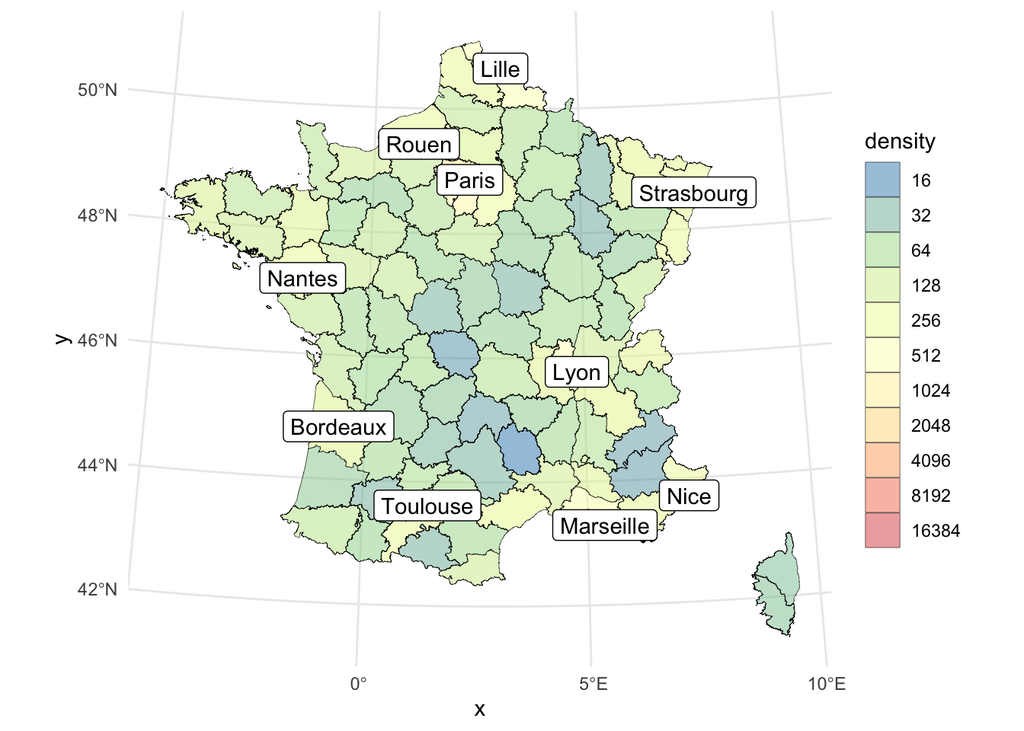

```r
dept %>%
  mutate(area = as.numeric(set_units(st_area(geometry), "km^2"))) %>%
  left_join(pop, by = "departement") %>%
  mutate(density = population / area) %>%
  slice(1:96) %>%
  st_transform(3943) %>%
  ggplot() +
    geom_sf(aes(fill = density), color = "black", size = 0.1, alpha = 0.5) +
    scale_fill_distiller(trans = "log2", palette = "Spectral", guide = "legend", n.breaks = 10) +
    geom_sf_label(aes(label = city), data = slice(cities, 1:10))
```

You can adjust the number of cities based on how large the plot is on your screen.

### Integrating the COVID-19 data

Finally, let’s integrate a bit of the COVID-19 data into our spatial analysis. Start by creating a dataset called `covid_april` by filtering the data to include only the data from “2020-04-30” and compute the number of COVID-19 deaths per 100k residents. This will require using the `pop` and `covid` datasets.

```r
covid_april <- covid %>%
  filter(date == "2020-04-30") %>%
  left_join(pop, by = "departement") %>%
  mutate(morality_rate = deceased / population * 100000)
covid_april
```

```
## # A tibble: 101 × 11
##    date       departement departement_name  deceased hospitalised reanimation
##    <date>     <chr>       <chr>                <dbl>        <dbl>       <dbl>
##  1 2020-04-30 01          Ain                     80          160          16
##  2 2020-04-30 02          Aisne                  209          286          37
##  3 2020-04-30 03          Allier                  26           44          14
##  4 2020-04-30 04          Alpes-de-Haute-P…        7           27           2
##  5 2020-04-30 05          Hautes-Alpes             8           35           6
##  6 2020-04-30 06          Alpes-Maritimes        134          238          52
##  7 2020-04-30 07          Ardèche                 67          145          14
##  8 2020-04-30 08          Ardennes                37           46           9
##  9 2020-04-30 09          Ariège                   2           10           1
## 10 2020-04-30 10          Aube                   111          230          17
## # … with 91 more rows, and 5 more variables: recovered <dbl>,
## #   hospitalised_new <dbl>, reanimation_new <dbl>, population <dbl>,
## #   morality_rate <dbl>
```

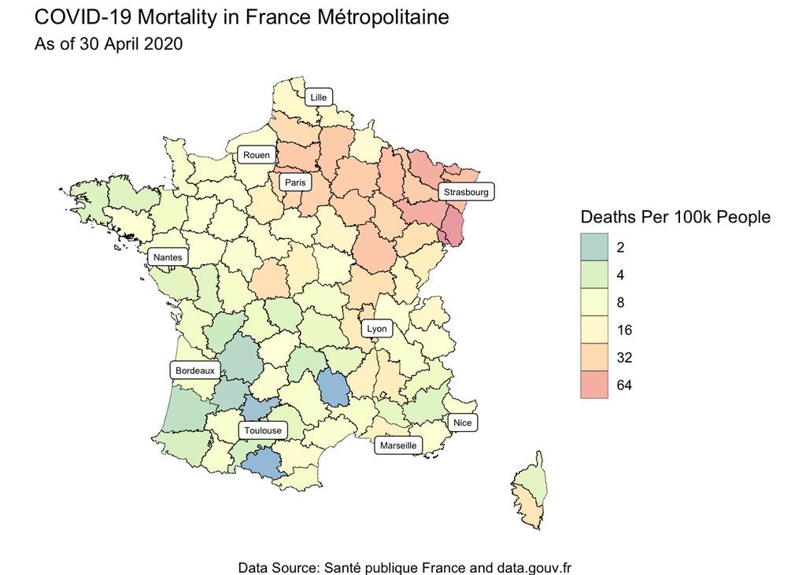

```r
# I added axis labels and titles; these were not required in the question
dept %>%
  mutate(area = as.numeric(set_units(st_area(geometry), "km^2"))) %>%
  left_join(covid_april, by = "departement") %>%
  slice(1:96) %>%
  st_transform(3943) %>%
  ggplot() +
    geom_sf(aes(fill = morality_rate), color = "black", size = 0.1, alpha = 0.5) +
    scale_fill_distiller(trans = "log2", palette = "Spectral", guide = "legend", n.breaks = 10) +
    geom_sf_label(aes(label = city), data = slice(cities, 1:10), size = 2) +
    labs(
      x = "", y = "", fill = "Deaths Per 100k People",
      title = "COVID-19 Mortality in France Métropolitaine",
      subtitle = "As of 30 April 2020",
      caption = "Data Source: Santé publique France and data.gouv.fr"
    ) +
    theme_void()
```

As a last step (you will find you can copy much of the previous code), show the number of people who were hospitalised per 100k residents on “2020-10-01”.

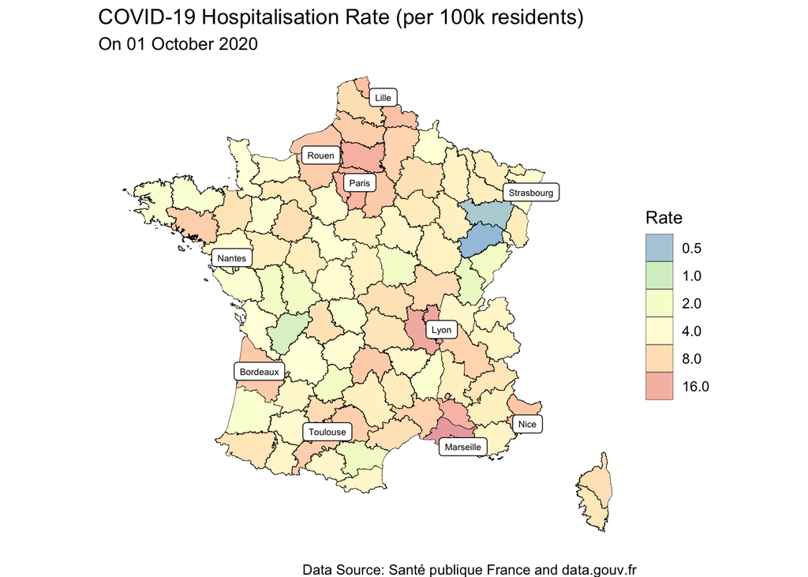

```r
covid_now <- covid %>%
  filter(date == "2020-10-01") %>%
  left_join(pop, by = "departement") %>%
  mutate(hosp_rate = hospitalised / population * 100000)

dept %>%
  mutate(area = as.numeric(set_units(st_area(geometry), "km^2"))) %>%
  left_join(covid_now, by = "departement") %>%
  slice(1:96) %>%
  st_transform(3943) %>%
  ggplot() +
    geom_sf(aes(fill = hosp_rate), color = "black", size = 0.1, alpha = 0.5) +
    scale_fill_distiller(trans = "log2", palette = "Spectral", guide = "legend", n.breaks = 10) +
    geom_sf_label(aes(label = city), data = slice(cities, 1:10), size = 2) +
    labs(
      x = "", y = "", fill = "Rate",
      title = "COVID-19 Hospitalisation Rate (per 100k residents)",
      subtitle = "On 01 October 2020",
      caption = "Data Source: Santé publique France and data.gouv.fr"
    ) +
    theme_void()
```

If you have time remaining, consider adding some labels to the last two plots to make them closer to something that you might include a published report. You might consider adding `theme_void` to minimize the ink used on the axes.